## Loading and preprocessing the data

```r
library(knitr)
library(ggplot2)
library(dplyr)
library(lubridate)
library(magrittr)
```

# Loading and preprocessing the data.

```r
data <- tbl_df(read.csv("./activity.csv",sep = ","))
```

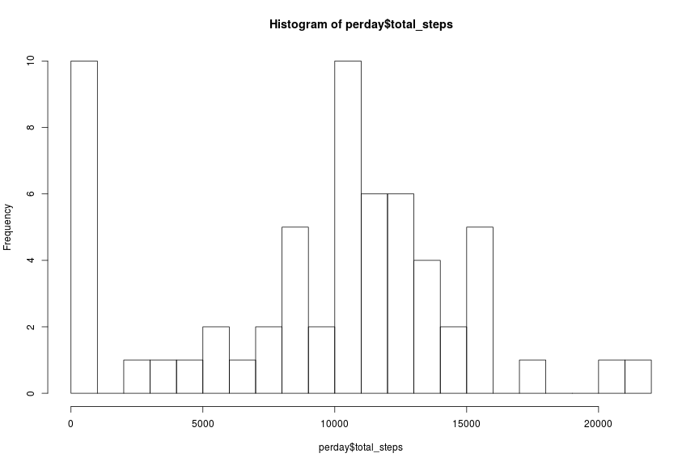

```r
perday <-  data %>% group_by( date ) %>% summarise( total_steps =sum(steps,na.rm=T ))
hist(perday$total_steps,breaks=30)
```

```r
perday_stats <- data %>%
   transmute( steps=ifelse(is.na(steps),0,steps), date=date,interval=interval) %>%
   summarise( mean_steps = mean(steps ), median_steps = median(steps,na.rm=T))
knitr::kable(perday_stats)
```

| mean_steps | median_steps |
| --- | --- |
| 32.47996 | 0 |

## What is the average daily activity pattern?

### The following chart is the average number of steps taken per 5 minute period

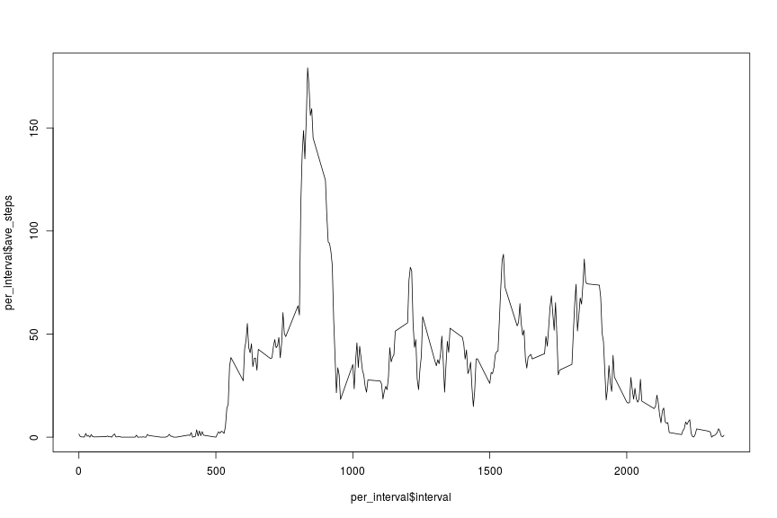

```r
per_interval <- data %>% transmute( steps=ifelse(is.na(steps),0,steps), date=date,interval=interval) %>%
   group_by( interval ) %>% summarise( ave_steps = mean(steps ))
plot(per_interval$interval,per_interval$ave_steps,type="l")
```

### The following interval represents the interval with the MOST number of steps

```r
index <- which(per_interval$ave_steps == max( per_interval$ave_steps ))
per_interval[index,]$interval
```

```
## [1] 835
```

## Dealing with missing values

First we need to find out the total number of missing values that we are dealing with. We can calculate it as follows:

### Determing the number of NA's in the dataset

```r
length(which(is.na(data$steps)))
```

```
## [1] 2304
```

### Employing a strategy for replacing the NA values with the average for the time interval

First save the average steps per each interval into the variable replacements.

```r
replacements <- data %>%
  filter( !is.na(steps)) %>%
  group_by(interval) %>%
  summarize( ave_steps = floor(mean(steps)))
```

Next, create a new dataset called **altered** that replaces steps with the average value for that interval.

```r
altered <- mutate(data, date=date,steps = ifelse(  is.na(steps) , replacements[which( interval == replacements$interval )]$ave_steps, steps))
```

Now lets perform a summary based on the total steps for those days using the new altered dataset that was created.

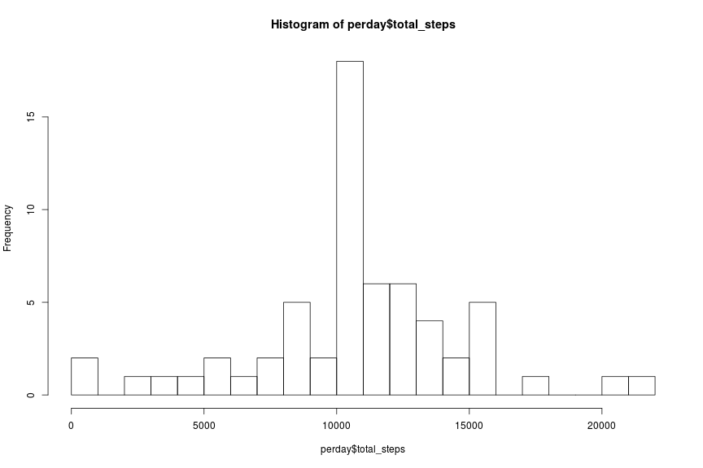

```r
perday <-  altered %>% group_by( date ) %>% summarise( total_steps =sum(steps ))
hist(perday$total_steps,breaks=30)
```

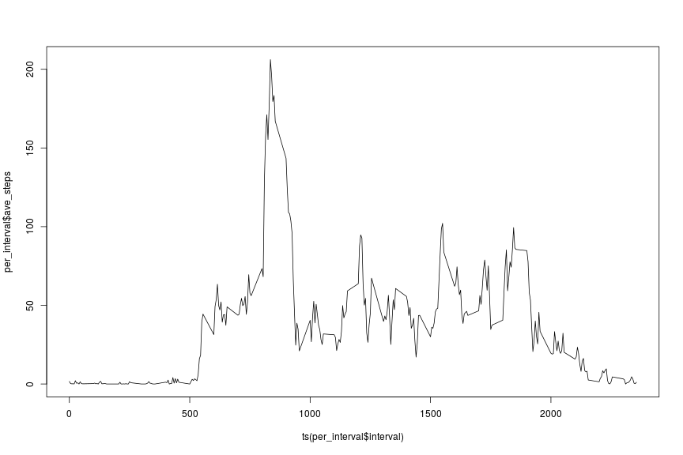

```r
per_interval <- altered %>% group_by( interval ) %>% summarise( ave_steps = mean(steps ))
plot( ts(per_interval$interval), per_interval$ave_steps , type="l")
```

```r
perday_stats <- altered %>%  summarise( mean_steps = mean(steps ), median_steps = median(steps))
knitr::kable(perday_stats)
```

| mean_steps | median_steps |
| --- | --- |
| 37.32559 | 0 |

## Are there differences in activity patterns between weekdays and weekends?

We will create a new dataset from the altered dataset and create a new column for the type of day being either a weekend or a weekday.

```r
newaltered <- altered %>%
  mutate(type_of_day=ifelse(weekdays(as.POSIXlt(date)) %in% c("Sunday","Saturday"),"weekend","weekday"))
```

Next we will create a new variable that contains the group by interval for each type of type of day to determine how the activity is affected by whether we are in a weekend or not.

```r
per_type_of_day <- newaltered %>%
    group_by( interval, type_of_day ) %>%
    summarise( mean_steps = mean(steps ) )
```

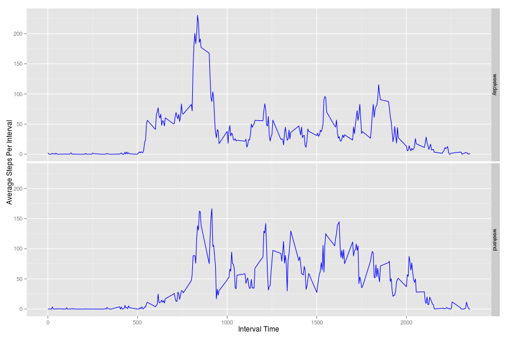

```r
p <- ggplot(per_type_of_day, aes(x=as.numeric(interval), y=mean_steps)) +
     facet_grid(type_of_day~.) + geom_line(colour="blue") +
     xlab("Interval Time")  + ylab("Average Steps Per Interval")
p
```